# STAT167 HW3 - Spring 2021

Deisy Diaz Vazquez

ddiaz022@ucr.edu

## **Homework #3 instructions**

**Review [textbook Chapter 3 “Data visualization”](https://r4ds.had.co.nz/data-visualisation.html) and lecture notes on `ggplot2` (2021/4/20 & 2021/4/22) before answering the homework questions**.

This homework contains 2 questions, each with multiple parts, 100 points in total.

Replace **INSERT_YOUR_ANSWER** with your own answers.

- First open this `rmd` file in RStudio and click `Knit -> Knit to HTML` to render it to HTML format.
- It is best to read this `rmd` file and the rendered `html` file side-by-side, while you are working on this homework.
- If the question asks you to write some R code, remember to put your code into a **R code chunk**. Make sure both your R code chunk and its output are visible in the rendered `html` file.
- For this homework, use **ggplot2** to visualize your data. Do **NOT** use R base graphics functions.
- **Please comment your R code thoroughly, and follow the R coding style guideline (https://google.github.io/styleguide/Rguide.xml). Partial credit will be deducted for insufficient commenting or poor coding styles.**
- If you have any question about this homework assignment, we encourage you to post it on [**Piazza**](http://piazza.com/ucr/spring2021/stat167/home).

### **Homework submission guideline**

- **This homework is DUE at *11:59 PM* on *Sunday April 25, 2021***.
- Late submission penalties.
  - Submissions up to 24 hours late will incur a 10% deduction.
  - Submissions up to 48 hours late will incur a 30% deduction.
- **If you are using one or both of your free late days, please state here:** **I will be using one of my free late passes.**
- After you complete all questions, save your `rmd` file to `FirstnameLastname-SID-HW3.rmd` and save the rendered `html` or `pdf` file to `FirstnameLastname-SID-HW3.html` or `FirstnameLastname-SID-HW3.pdf`.
- Submit **BOTH your source `rmd` file and the knitted `html` or `pdf` file** to **GradeScope**. Do NOT create a zip file. You can submit multiple times, you last submission will be graded.

## **Acknowledgments**

Please list all the help you have received for completing this homework.

**Load necessary packages**

```r
# install the tidyverse package first if you have not done it yet.
#install.packages("tidyverse") # you can comment out this line after you have installed `tidyverse`

library(tidyverse) # for the `ggplot2` package
```

## **Question 1 [40pt] Visualization of the `mpg` data set**

This data set contains fuel economy data 1999 - 2008 for 38 popular car models (source: EPA http://fueleconomy.gov).

```r
?mpg
## starting httpd help server ... done
dim(mpg)  # dimension of the table
```

```
## [1] 234  11
```

```r
names(mpg)  # list the variables in mpg
```

```
##  [1] "manufacturer" "model"        "displ"        "year"         "cyl"
##  [6] "trans"        "drv"          "cty"          "hwy"          "fl"
## [11] "class"
```

```r
str(mpg)  # list the structures in mpg
## tibble [234 x 11] (S3: tbl_df/tbl/data.frame)
##  $ manufacturer: chr [1:234] "audi" "audi" "audi" "audi" ...
##  $ model       : chr [1:234] "a4" "a4" "a4" "a4" ...
##  $ displ       : num [1:234] 1.8 1.8 2 2 2.8 2.8 3.1 1.8 1.8 2 ...
##  $ year        : int [1:234] 1999 1999 2008 2008 1999 1999 2008 1999 1999 2008 ...
##  $ cyl         : int [1:234] 4 4 4 4 6 6 6 4 4 4 ...
##  $ trans       : chr [1:234] "auto(l5)" "manual(m5)" "manual(m6)" "auto(av)" ...
##  $ drv         : chr [1:234] "f" "f" "f" "f" ...
##  $ cty         : int [1:234] 18 21 20 21 16 18 18 18 16 20 ...
##  $ hwy         : int [1:234] 29 29 31 30 26 26 27 26 25 28 ...
##  $ fl          : chr [1:234] "p" "p" "p" "p" ...
##  $ class       : chr [1:234] "compact" "compact" "compact" "compact" ...
glimpse(mpg) # get a glimpse of the mpg data
```

```
## Rows: 234
## Columns: 11
## $ manufacturer <chr> "audi", "audi", "audi", "audi", "audi", "audi", "audi"...
## $ model        <chr> "a4", "a4", "a4", "a4", "a4", "a4", "a4", "a4 quattro"...
## $ displ        <dbl> 1.8, 1.8, 2.0, 2.0, 2.8, 2.8, 3.1, 1.8, 1.8, 2.0, 2.0,...
## $ year         <int> 1999, 1999, 2008, 2008, 1999, 1999, 2008, 1999, 1999, ...
## $ cyl          <int> 4, 4, 4, 4, 6, 6, 6, 4, 4, 4, 4, 6, 6, 6, 6, 6, 6, 8, ...
## $ trans        <chr> "auto(l5)", "manual(m5)", "manual(m6)", "auto(av)", "a...
## $ drv          <chr> "f", "f", "f", "f", "f", "f", "f", "4", "4", "4", "4",...
## $ cty          <int> 18, 21, 20, 21, 16, 18, 18, 18, 16, 20, 19, 15, 17, 17...
## $ hwy          <int> 29, 29, 31, 30, 26, 26, 27, 26, 25, 28, 27, 25, 25, 25...
## $ fl           <chr> "p", "p", "p", "p", "p", "p", "p", "p", "p", "p", "p",...
## $ class        <chr> "compact", "compact", "compact", "compact", "compact",...
```

### (a) [20pt] Visualize the distribution of drive train types

1. Draw a barplot (frequency histogram) to display the distribution of `drv`, the type of drive train. Use different colors to distinguish different drive train types. Explicitly label the number of car models of each drive train type on top of the bars.

**ANSWER**

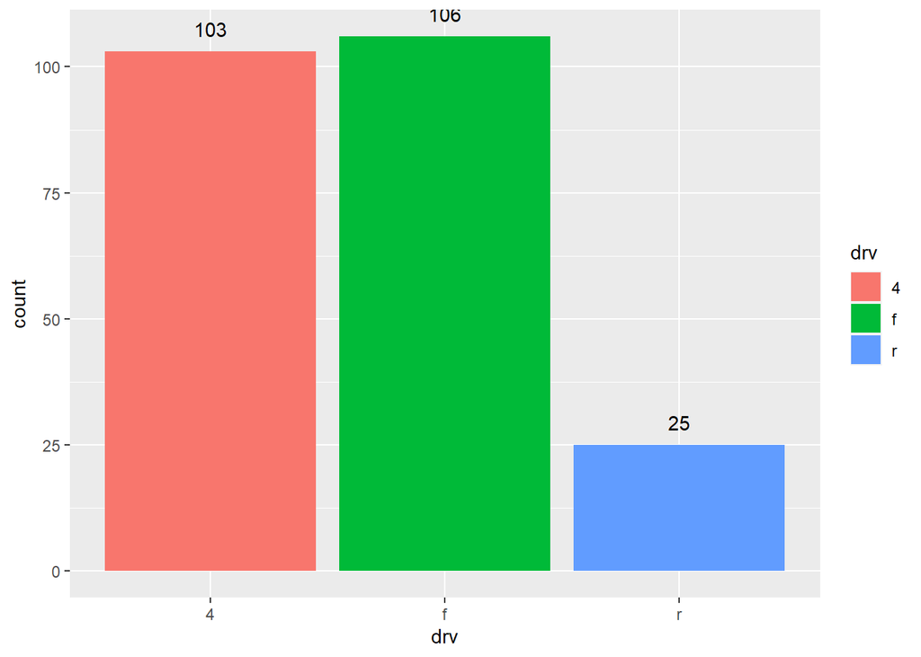

```r
# Enter your code here
ggplot(data = mpg, mapping = aes(x = drv, fill = drv)) + # load mpg data with x = drv and fill by drive
  geom_bar() + # bar plot
  geom_text(stat = 'count', # use stat count method
            mapping = aes(label = ..count..),
            vjust = -1)
```

2. Draw a coxcomb or pie chart to display the proportions of each drive train types.

**ANSWER**

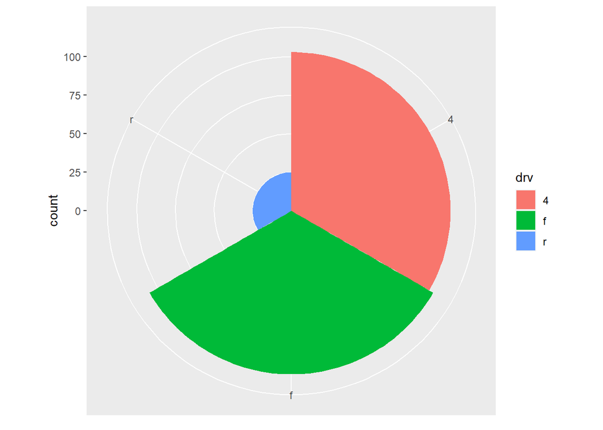

```r
# Enter your code here
ggplot(data = mpg) + # load mpg data
  geom_bar(mapping = aes(x = drv, fill = drv), #plot bar
           width = 1) +
  theme(aspect.ratio = 1)+
  labs(x = NULL) +
  coord_polar() # change bar type plot
```

### (b) [20pt] How highway mileage varies across drive train type?

Generate a horizontal boxplot to compare the distribution of highway mileage across three different drive train types. Reorder the boxes by the median mileage values.

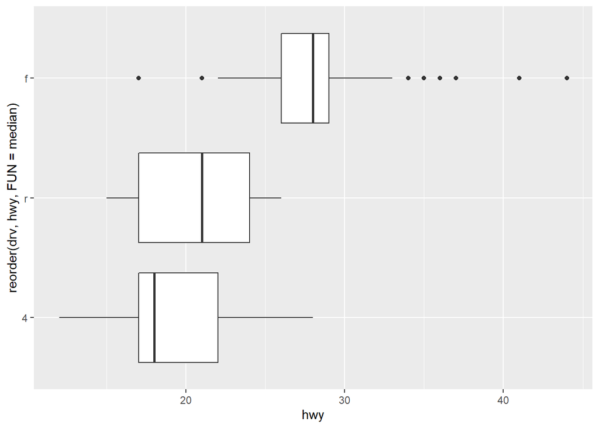

```r
# Enter your code here
ggplot(data = mpg) + # load mpg data
  geom_boxplot(mapping = aes(x = reorder(drv, hwy, FUN = median), y = hwy)) + # bpxplot with x = drv, y = hwy, order by median
  coord_flip() # change orientation to horizontal
```

## **Question 2 [60pt] Visualization the `diamonds` data set**

This data set contains the prices and other attributes of almost 54,000 diamonds.

```r
?diamonds
dim(diamonds)  # dimension of the table
```

```
## [1] 53940    10
```

```r
diamonds # print/view diamonds
```

```
## # A tibble: 53,940 x 10
##    carat cut       color clarity depth table price     x     y     z
##    <dbl> <ord>     <ord> <ord>   <dbl> <dbl> <int> <dbl> <dbl> <dbl>
##  1 0.23  Ideal     E     SI2      61.5    55   326  3.95  3.98  2.43
##  2 0.21  Premium   E     SI1      59.8    61   326  3.89  3.84  2.31
##  3 0.23  Good      E     VS1      56.9    65   327  4.05  4.07  2.31
##  4 0.290 Premium   I     VS2      62.4    58   334  4.2   4.23  2.63
##  5 0.31  Good      J     SI2      63.3    58   335  4.34  4.35  2.75
##  6 0.24  Very Good J     VVS2     62.8    57   336  3.94  3.96  2.48
##  7 0.24  Very Good I     VVS1     62.3    57   336  3.95  3.98  2.47
##  8 0.26  Very Good H     SI1      61.9    55   337  4.07  4.11  2.53
##  9 0.22  Fair      E     VS2      65.1    61   337  3.87  3.78  2.49
## 10 0.23  Very Good H     VS1      59.4    61   338  4     4.05  2.39
## # ... with 53,930 more rows
```

```r
str(diamonds)  # list the structures in diamonds
## tibble [53,940 x 10] (S3: tbl_df/tbl/data.frame)
##  $ carat  : num [1:53940] 0.23 0.21 0.23 0.29 0.31 0.24 0.24 0.26 0.22 0.23 ...
##  $ cut    : Ord.factor w/ 5 levels "Fair"<"Good"<..: 5 4 2 4 2 3 3 3 1 3 ...
##  $ color  : Ord.factor w/ 7 levels "D"<"E"<"F"<"G"<..: 2 2 2 6 7 7 6 5 2 5 ...
##  $ clarity: Ord.factor w/ 8 levels "I1"<"SI2"<"SI1"<..: 2 3 5 4 2 6 7 3 4 5 ...
##  $ depth  : num [1:53940] 61.5 59.8 56.9 62.4 63.3 62.8 62.3 61.9 65.1 59.4 ...
##  $ table  : num [1:53940] 55 61 65 58 58 57 57 55 61 61 ...
##  $ price  : int [1:53940] 326 326 327 334 335 336 336 337 337 338 ...
##  $ x      : num [1:53940] 3.95 3.89 4.05 4.2 4.34 3.94 3.95 4.07 3.87 4 ...
##  $ y      : num [1:53940] 3.98 3.84 4.07 4.23 4.35 3.96 3.98 4.11 3.78 4.05 ...
##  $ z      : num [1:53940] 2.43 2.31 2.31 2.63 2.75 2.48 2.47 2.53 2.49 2.39 ...
glimpse(diamonds) # get a glimpse of the data
```

```
## Rows: 53,940
## Columns: 10
## $ carat   <dbl> 0.23, 0.21, 0.23, 0.29, 0.31, 0.24, 0.24, 0.26, 0.22, 0.23,...
## $ cut     <ord> Ideal, Premium, Good, Premium, Good, Very Good, Very Good, ...
## $ color   <ord> E, E, E, I, J, J, I, H, E, H, J, J, F, J, E, E, I, J, J, J,...
## $ clarity <ord> SI2, SI1, VS1, VS2, SI2, VVS2, VVS1, SI1, VS2, VS1, SI1, VS...
## $ depth   <dbl> 61.5, 59.8, 56.9, 62.4, 63.3, 62.8, 62.3, 61.9, 65.1, 59.4,...
## $ table   <dbl> 55, 61, 65, 58, 58, 57, 57, 55, 61, 61, 55, 56, 61, 54, 62,...
## $ price   <int> 326, 326, 327, 334, 335, 336, 336, 337, 337, 338, 339, 340,...
## $ x       <dbl> 3.95, 3.89, 4.05, 4.20, 4.34, 3.94, 3.95, 4.07, 3.87, 4.00,...
## $ y       <dbl> 3.98, 3.84, 4.07, 4.23, 4.35, 3.96, 3.98, 4.11, 3.78, 4.05,...
## $ z       <dbl> 2.43, 2.31, 2.31, 2.63, 2.75, 2.48, 2.47, 2.53, 2.49, 2.39,...
```

### (a) [20pt] Heatmap of `cut` vs `clarity`

1. Use [the `geom_tile()` function](https://ggplot2.tidyverse.org/reference/geom_tile.html) to make a heatmap to visualize the number of diamonds in each `cut` and `clarity` combination.

**ANSWER**

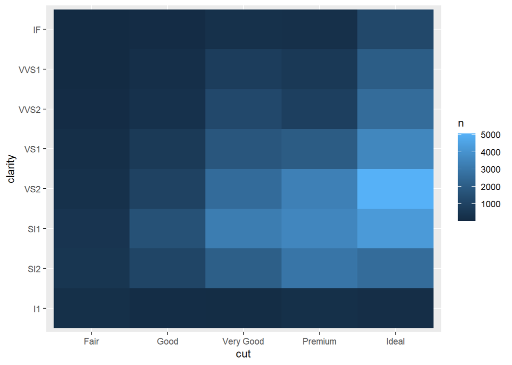

```r
# Enter your code here

ggplot(data = count(x = diamonds, cut, clarity)) + # load diamond data, cut and clarity
geom_tile(mapping = aes(x = cut, y = clarity, fill = n)) # plot tile by x = cut, y = clatiy, and fill by count
```

2. Change the color palette of your heatmap.

**Hint**: See [these heatmap examples at the R Graph Gallery](https://www.r-graph-gallery.com/79-levelplot-with-ggplot2.html).

**ANSWER**

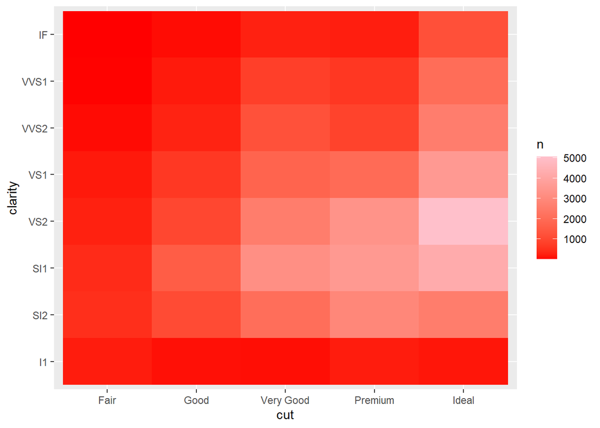

```r
# Enter your code here

ggplot(data = count(x = diamonds, cut, clarity)) + # load diamond data, cut and clarity
geom_tile(mapping = aes(x = cut, y = clarity, fill = n)) + # plot tile by x = cut, y = clatiy, and fill by count
  scale_fill_gradient(low = "red", high = "pink") # fill gradient by red for low and pink for high count
```